# Canton

B. Maranget

22/02/2021

# 1 Cadre

## 1.1 Objet

Créer trois cartes issues de deux bases de données différentes : - mais semence (Enquêtes AGPM Maïs Semence 2019) - mais doux (rpg 2019) et une carte de ratio doux / semence

Ce projet permet de faire le point sur les différentes sources pour les cantons. En effet, dans les fichiers geofla, c’est l’identifiant geofla qui est unique et le nom du canton n’apparaît pas. Le code canton est constitué du numéro de département et du code canton n’est pas unique. Le nom du chef lieu n’est pas toujours présent.

Un fichier récupéré sur datagouv, produit par l’IGN, ne comporte pas l’id geofla mais a un nom canton. Remarque ce fichier date de 2015 également, les ID de canton (num dpt et code canton sont uniques) https://www.data.gouv.fr/fr/datasets/decoupage-des-cantons-pour-les-elections-departementales-de-mars-2015/ droits : “IGN”

Comme il s’agit de faire correspondre les données de deux régions uniquement (Nouvelle Aquitaine et Occitanie, voire même plutôt des anciennes régions puisque les données de la géométrie des cantons datent de 2015 Aquitaine et Midi pyrénées), la technique choisie est d’associer les fichiers géométries de canton utilisées avec le rpg 2019 (geofla 2015) par l’id canton et à traiter au cas par cas les doublons (jointure attributaire pas d’intersection spatiale)

## 1.2 Librairies

```r
library("sf")
```

```r
library("mapview") # pour exploration de la donnée
library("cartography")
```

## 1.3 Données

```r
cantonGeofla <- st_read("../dataE/00_ADMIN/canton2015/CANTON.SHP", quiet = TRUE, stringsAsFactors = F)
cantonOpenData <- st_read("../dataE/00_ADMIN/canton2015opendata/Cantons_2015_WGS4G.shp",
                          options = "ENCODING=WINDOWS-1252",quiet = T, stringsAsFactors =F)
# fond européen pour représenter voisinage géographique des deux régions
fond <-  st_read("../dataE/00_ADMIN/nuts.gpkg", "pays")
fond <- st_transform(fond, 2154)
st_crs(fond)
```

```
## Coordinate Reference System:
##   User input: RGF93 / Lambert-93
##   wkt:
## PROJCRS["RGF93 / Lambert-93",
##     BASEGEOGCRS["RGF93",
##         DATUM["Reseau Geodesique Francais 1993",
##             ELLIPSOID["GRS 1980",6378137,298.257222101,
##                 LENGTHUNIT["metre",1]]],
##         PRIMEM["Greenwich",0,
##             ANGLEUNIT["degree",0.0174532925199433]],
##         ID["EPSG",4171]],
##     CONVERSION["Lambert-93",
##         METHOD["Lambert Conic Conformal (2SP)",
##             ID["EPSG",9802]],
##         PARAMETER["Latitude of false origin",46.5,
##             ANGLEUNIT["degree",0.0174532925199433],
##             ID["EPSG",8821]],
##         PARAMETER["Longitude of false origin",3,
##             ANGLEUNIT["degree",0.0174532925199433],
##             ID["EPSG",8822]],
##         PARAMETER["Latitude of 1st standard parallel",49,
##             ANGLEUNIT["degree",0.0174532925199433],
##             ID["EPSG",8823]],
##         PARAMETER["Latitude of 2nd standard parallel",44,
##             ANGLEUNIT["degree",0.0174532925199433],
##             ID["EPSG",8824]],
##         PARAMETER["Easting at false origin",700000,
##             LENGTHUNIT["metre",1],
##             ID["EPSG",8826]],
##         PARAMETER["Northing at false origin",6600000,
##             LENGTHUNIT["metre",1],
##             ID["EPSG",8827]]],
##     CS[Cartesian,2],
##         AXIS["easting (X)",east,
##             ORDER[1],
##             LENGTHUNIT["metre",1]],
##         AXIS["northing (Y)",north,
##             ORDER[2],
##             LENGTHUNIT["metre",1]],
##     USAGE[
##         SCOPE["unknown"],
##         AREA["France"],
##         BBOX[41.15,-9.86,51.56,10.38]],
##     ID["EPSG",2154]]
```

```r
fondRegion <- st_read("../dataE/00_ADMIN/ign.gpkg", "region")
fondRegion <- st_transform(fondRegion,2154)
st_crs(fondRegion)
```

```
## Coordinate Reference System:
##   User input: RGF93 Lambert 93
##   wkt:
## PROJCRS["RGF93 Lambert 93",
##     BASEGEOGCRS["RGF93 geographiques (dms)",
##         DATUM["Reseau Geodesique Francais 1993",
##             ELLIPSOID["GRS 1980",6378137,298.257222101,
##                 LENGTHUNIT["metre",1]]],
##         PRIMEM["Greenwich",0,
##             ANGLEUNIT["degree",0.0174532925199433]],
##         ID["IGNF","RGF93G"]],
##     CONVERSION["unnamed",
##         METHOD["Lambert Conic Conformal (2SP)",
##             ID["EPSG",9802]],
##         PARAMETER["Latitude of false origin",46.5,
##             ANGLEUNIT["degree",0.0174532925199433],
##             ID["EPSG",8821]],
##         PARAMETER["Longitude of false origin",3,
##             ANGLEUNIT["degree",0.0174532925199433],
##             ID["EPSG",8822]],
##         PARAMETER["Latitude of 1st standard parallel",44,
##             ANGLEUNIT["degree",0.0174532925199433],
##             ID["EPSG",8823]],
##         PARAMETER["Latitude of 2nd standard parallel",49,
##             ANGLEUNIT["degree",0.0174532925199433],
##             ID["EPSG",8824]],
##         PARAMETER["Easting at false origin",700000,
##             LENGTHUNIT["metre",1],
##             ID["EPSG",8826]],
##         PARAMETER["Northing at false origin",6600000,
##             LENGTHUNIT["metre",1],
##             ID["EPSG",8827]]],
##     CS[Cartesian,2],
##         AXIS["easting",east,
##             ORDER[1],
##             LENGTHUNIT["metre",1]],
##         AXIS["northing",north,
##             ORDER[2],
##             LENGTHUNIT["metre",1]],
##     ID["IGNF","LAMB93"]]
```

```r
# bizarre ces deux crs qui ne correspondent pas ....
# encodage pour cas côte d'argent, l'apostrophe ne passait pas
```

# 2 Vérification identifiant canton

Pour pouvoir lier cantons geofla et opendata, il faut examiner les clés des deux bases cantons.

## 2.1 Geofla : des doublons sur le CANTON_NUM

```r
str(cantonGeofla)
```

```
## Classes 'sf' and 'data.frame':   2378 obs. of  17 variables:
##  $ ID_GEOFLA : chr  "CANTON000000000000000001" "CANTON000000000000000002" "CANTON000000000000000003" "CANTON000000000000000004" ...
##  $ CODE_CANT : chr  "08" "15" "01" "23" ...
##  $ CODE_CHF  : chr  "127" NA NA NA ...
##  $ NOM_CHF   : chr  "CAPVERN" NA NA NA ...
##  $ X_CHF_LIEU: int  481427 0 0 0 667817 0 364643 603437 434661 930221 ...
##  $ Y_CHF_LIEU: int  6226201 0 0 0 6840293 0 6781526 7047552 6236686 6893486 ...
##  $ X_CENTROID: int  478321 955582 491175 404866 669845 653153 368073 605615 429920 929326 ...
##  $ Y_CENTROID: int  6193701 6661505 6785550 6410045 6838911 6986265 6787120 7047716 6238801 6894625 ...
##  $ CODE_ARR  : chr  "2" "3" "3" "2" ...
##  $ CODE_DEPT : chr  "65" "25" "72" "33" ...
##  $ NOM_DEPT  : chr  "HAUTES-PYRENEES" "DOUBS" "SARTHE" "GIRONDE" ...
##  $ CODE_REG  : chr  "73" "43" "52" "72" ...
##  $ NOM_REG   : chr  "MIDI-PYRENEES" "FRANCHE-COMTE" "PAYS DE LA LOIRE" "AQUITAINE" ...
##  $ Code_canto: chr  "6508" "2515" "7201" "3323" ...
##  $ CANTON_NUM: int  6508 2515 7201 3323 7704 8007 3505 6224 6417 5715 ...
##  $ SURFBIO   : num  41 119 NA NA NA ...
##  $ geometry  :sfc_MULTIPOLYGON of length 2378; first list element: List of 1
##   ..$ :List of 1
##   .. ..$ : num [1:716, 1:2] 484386 483580 482335 481490 481470 ...
##   ..- attr(*, "class")= chr  "XY" "MULTIPOLYGON" "sfg"
##  - attr(*, "sf_column")= chr "geometry"
##  - attr(*, "agr")= Factor w/ 3 levels "constant","aggregate",..: NA NA NA NA NA NA NA NA NA NA ...
##   ..- attr(*, "names")= chr  "ID_GEOFLA" "CODE_CANT" "CODE_CHF" "NOM_CHF" ...
```

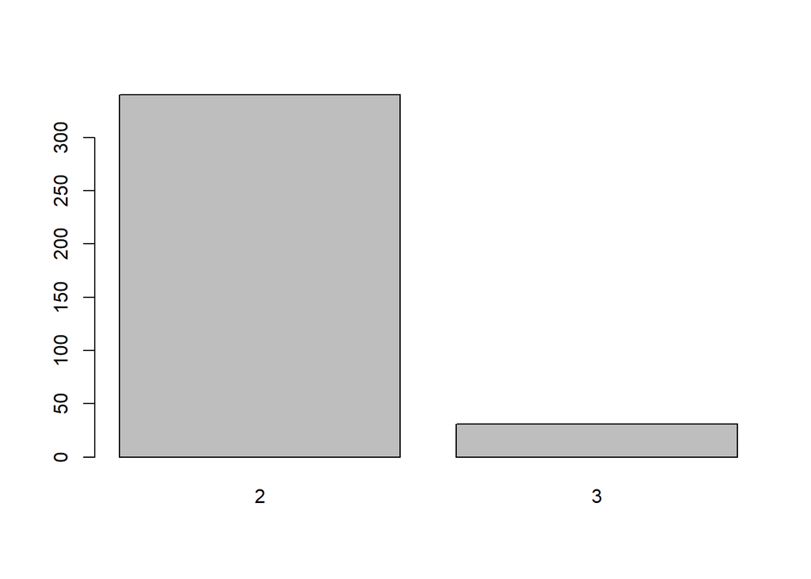

```r
# 2378 obs
tab <- table(cantonGeofla$CANTON_NUM)
doublons <-tab [ tab > 1]
barplot(table(doublons))
```

```r
# plus de 300 doublons !
```

Donc le nom du dpt et le num canton ne suffit pas.

TODO pourquoi pas nom de canton dans Geofla ?

### 2.1.1 Cartographie des triplets

```r
triplets <- tab [ tab ==3]
cantonSel <- cantonGeofla [cantonGeofla$CANTON_NUM %in% names(triplets),]
str(cantonGeofla)
```

```
## Classes 'sf' and 'data.frame':   2378 obs. of  17 variables:
##  $ ID_GEOFLA : chr  "CANTON000000000000000001" "CANTON000000000000000002" "CANTON000000000000000003" "CANTON000000000000000004" ...
##  $ CODE_CANT : chr  "08" "15" "01" "23" ...
##  $ CODE_CHF  : chr  "127" NA NA NA ...
##  $ NOM_CHF   : chr  "CAPVERN" NA NA NA ...
##  $ X_CHF_LIEU: int  481427 0 0 0 667817 0 364643 603437 434661 930221 ...
##  $ Y_CHF_LIEU: int  6226201 0 0 0 6840293 0 6781526 7047552 6236686 6893486 ...
##  $ X_CENTROID: int  478321 955582 491175 404866 669845 653153 368073 605615 429920 929326 ...
##  $ Y_CENTROID: int  6193701 6661505 6785550 6410045 6838911 6986265 6787120 7047716 6238801 6894625 ...
##  $ CODE_ARR  : chr  "2" "3" "3" "2" ...
##  $ CODE_DEPT : chr  "65" "25" "72" "33" ...
##  $ NOM_DEPT  : chr  "HAUTES-PYRENEES" "DOUBS" "SARTHE" "GIRONDE" ...
##  $ CODE_REG  : chr  "73" "43" "52" "72" ...
##  $ NOM_REG   : chr  "MIDI-PYRENEES" "FRANCHE-COMTE" "PAYS DE LA LOIRE" "AQUITAINE" ...
##  $ Code_canto: chr  "6508" "2515" "7201" "3323" ...
##  $ CANTON_NUM: int  6508 2515 7201 3323 7704 8007 3505 6224 6417 5715 ...
##  $ SURFBIO   : num  41 119 NA NA NA ...
##  $ geometry  :sfc_MULTIPOLYGON of length 2378; first list element: List of 1
##   ..$ :List of 1
##   .. ..$ : num [1:716, 1:2] 484386 483580 482335 481490 481470 ...
##   ..- attr(*, "class")= chr  "XY" "MULTIPOLYGON" "sfg"
##  - attr(*, "sf_column")= chr "geometry"
##  - attr(*, "agr")= Factor w/ 3 levels "constant","aggregate",..: NA NA NA NA NA NA NA NA NA NA ...
##   ..- attr(*, "names")= chr  "ID_GEOFLA" "CODE_CANT" "CODE_CHF" "NOM_CHF" ...
```

```r
#mapview(cantonSel, popup = c("CANTON_NUM" ,"NOM_CHF"))
```

TODO Mapview provoque erreur dans markdown

Les triplets apparaissent partout sur le territoire français, à noter le cas de la Seine et Marne, gros département par excellence.

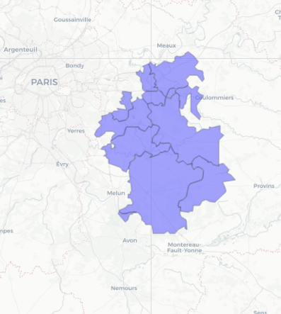

## 2.2 Opendata : pas de doublon ID_CAN et netttoyage nom

Il n’y a pas de doublon sur ID_CAN. Pour pouvoir établir la jointure avec la donnée d’enquête, on nettoie le champs nom.

La fonction de nettoyage utilisée provient d’internet (https://pt.stackoverflow.com/questions/46473/remover-acentos), elle est utilisée car elle semble exhaustive et permet de s’abstraire des problèmes encodages windows / linux.

```r
 rm_accent <- function(str,pattern="all") {
   if(!is.character(str))
    str <- as.character(str)

  pattern <- unique(pattern)

  if(any(pattern=="Ç"))
    pattern[pattern=="Ç"] <- "ç"

  symbols <- c(
    acute = "áéíóúÁÉÍÓÚýÝ",
    grave = "àèìòùÀÈÌÒÙ",
    circunflex = "âêîôûÂÊÎÔÛ",
    tilde = "ãõÃÕñÑ",
    umlaut = "äëïöüÄËÏÖÜÿ",
    cedil = "çÇ"
  )

  nudeSymbols <- c(
    acute = "aeiouAEIOUyY",
    grave = "aeiouAEIOU",
    circunflex = "aeiouAEIOU",
    tilde = "aoAOnN",
    umlaut = "aeiouAEIOUy",
    cedil = "cC"
  )

  accentTypes <- c("´","`","^","~","¨","ç")

  if(any(c("all","al","a","todos","t","to","tod","todo")%in%pattern)) # opcao retirar todos
    return(chartr(paste(symbols, collapse=""), paste(nudeSymbols, collapse=""), str))

  for(i in which(accentTypes%in%pattern))
    str <- chartr(symbols[i],nudeSymbols[i], str)

  return(str)
}
```

```r
tab <- table(cantonOpenData$ID_CAN)
cantonOpenData$NOM_CAN2 <- rm_accent(cantonOpenData$NOM_CAN)
# cas des tirets, on les supprime tous
cantonOpenData$NOM_CAN2 <- gsub ("-", " ", toupper(cantonOpenData$NOM_CAN2))
```

On observe que 7714 devient 7711 et 7714

# 3 Import mais doux avec nom canton

```r
data <- read.csv2("../dataE/01_CULTURES/maisdoux.csv", sep = "\t",
                  stringsAsFactors = FALSE)
str(data)
```

```
## 'data.frame':    126 obs. of  4 variables:
##  $ CP          : int  40 32 47 47 81 81 33 32 64 32 ...
##  $ CANTON      : chr  "ADOUR ARMAGNAC" "ADOUR GERSOISE" "AGEN 1" "AGEN 2" ...
##  $ SURFACE.MS  : chr  "1571.32" "2708.25" "24.1" "18.3" ...
##  $ CANTON_MODIF: chr  "" "" "" "" ...
```

```r
head(data$CANTON)
```

```
## [1] "ADOUR ARMAGNAC" "ADOUR GERSOISE" "AGEN 1"         "AGEN 2"
## [5] "ALBI"           "ALBI 3"
```

```r
data$CANTON2 <- gsub("-", " ", data$CANTON)
data$CANTON2 <- rm_accent(data$CANTON2)
data$CANTON2 <- ifelse((data$CANTON_MODIF==""), data$CANTON2, data$CANTON_MODIF)
```

```r
dataf <- merge(data, cantonOpenData, by.x = "CANTON2", by.y = "NOM_CAN2")
diff <- setdiff(data$CANTON2, dataf$CANTON2)
diff
```

```
## [1] "PELLEGRUE"
```

```r
# noms colonnes dataf
dataf <- dataf [,c("ID_CAN", "NOM_CAN", "SURFACE.MS", "geometry") ]
# le canton Pellegrue n'a pas de référence dans la table canton. Il a été fusionné.
cantonOpenData [grep("REOLAIS",cantonOpenData$NOM_CAN2),]
```

```
## Simple feature collection with 1 feature and 5 fields
## geometry type:  MULTIPOLYGON
## dimension:      XY
## bbox:           xmin: -0.2383232 ymin: 44.42302 xmax: 0.3150602 ymax: 44.8725
## geographic CRS: WGS 84
##      ID_CAN                    NOM_CAN CODE_CAN CODE_DEP
## 1824   3327 Le Réolais et Les Bastides       27       33
##                            geometry                   NOM_CAN2
## 1824 MULTIPOLYGON (((-0.1095017 ... LE REOLAIS ET LES BASTIDES
```

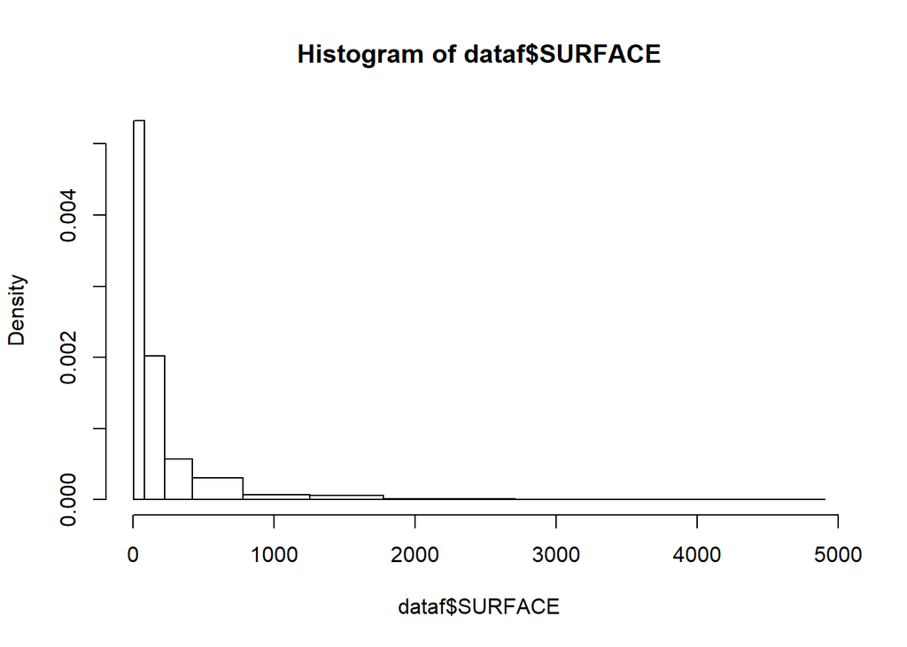

```r
i <- as.numeric (data$SURFACE.MS [data$CANTON2 == diff])
# on additionne donc la valeur de Pellegrue au Reolais
dataf$SURFACE <- as.numeric(dataf$SURFACE.MS)
dataf$SURFACE [grep("REOLAIS",data$CANTON2)] <- dataf$SURFACE [grep("REOLAIS",data$CANTON2)]+ i
bks <- getBreaks(v = dataf$SURFACE, nclass = 8, method = "jenks")
hist(dataf$SURFACE, breaks = bks, freq = FALSE)
```

```r
dataf <- st_as_sf(dataf)
dataf <- st_transform(dataf,2154)
```

# 4 Cartographie mais semence

```r
# au final, discretisation chiffres ronds
bks
```

```
## [1]    3.00   79.65  222.45  417.40  779.50 1252.41 1773.87 2708.25 4902.37
```

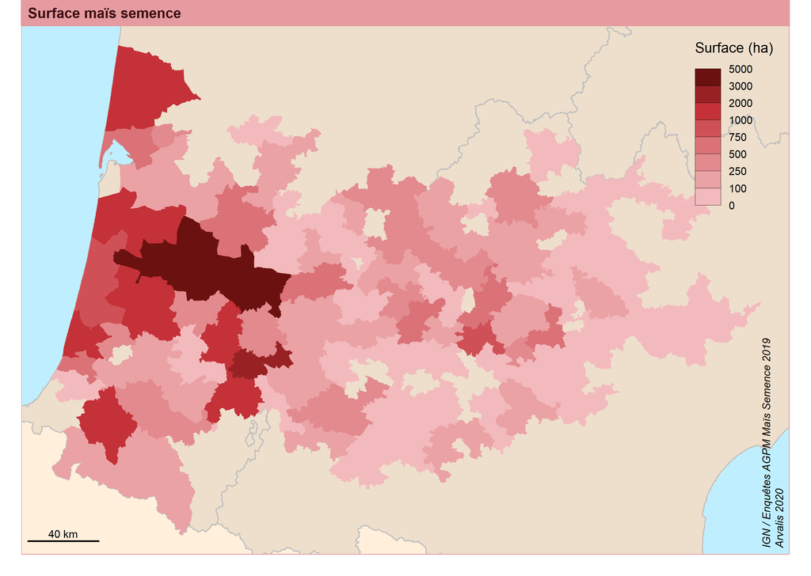

```r
breaks <- c(0,100, 250,500,750,1000,2000,3000,5000)
sizes <- getFigDim(x = dataf, width = 3000, mar = c(1,1,1.2,1), res = 400)
  png("../img/maissemence.png", height = sizes [2], width = sizes [1], res = 400)
  par(mar = c(1,1,1.2,1))
  # marge pour affichage correcte sources
  my.pal <- carto.pal("wine.pal", 8)
  ghostLayer(dataf, bg = "lightblue1")
  plot(fond, col = "antiquewhite1", border = "white", add = TRUE)
  plot(fondRegion, col = "antiquewhite2", border= "grey",lwd = 1, add = TRUE)
  choroLayer(dataf, var = "SURFACE",
             legend.title.txt = "Surface (ha)", legend.pos = "topright",
             breaks = breaks, col = my.pal, nclass = 9 , border = NA, add = TRUE)
  layoutLayer(title = "Surface maïs semence", author = "Arvalis 2020", sources = "IGN / Enquêtes AGPM Maïs Semence 2019", horiz = FALSE,
              posscale = "bottomleft", theme = "wine.pal")
  dev.off()
```